# A1_Gillette_20204160.Rmd

EGillette (20204160)

2025-01-08

## Running the dataGenerato.R script

https://github.com/EmiliagG/BIOL432_Assignment1

This script uses for loops to generate a dataframe with four variables: Organism, Limb width, Limb length, and Observer. The script then writes the data frame out to a csv.file. For Limb width and Limb length, the values are randomly selected from normal distributions around a means of 2 +/- 0.5 and 5 +/- 2, respectively.

```r
DataGenerato<-source('dataGenerato.R')
```

```
##   [1] "Danaus plexippus"      "Cirsium vulgare"       "Danaus plexippus"
##   [4] "Cirsium vulgare"       "Danaus plexippus"      "Cardinalis cardinalis"
##   [7] "Danaus plexippus"      "Cirsium vulgare"       "Cirsium vulgare"
##  [10] "Danaus plexippus"      "Cardinalis cardinalis" "Cardinalis cardinalis"
##  [13] "Cardinalis cardinalis" "Cardinalis cardinalis" "Betula papyrifera"
##  [16] "Vulpes vulpes"         "Cirsium vulgare"       "Cardinalis cardinalis"
##  [19] "Danaus plexippus"      "Betula papyrifera"     "Cardinalis cardinalis"
##  [22] "Danaus plexippus"      "Vulpes vulpes"         "Cirsium vulgare"
##  [25] "Cardinalis cardinalis" "Danaus plexippus"      "Betula papyrifera"
##  [28] "Vulpes vulpes"         "Cardinalis cardinalis" "Vulpes vulpes"
##  [31] "Betula papyrifera"     "Cirsium vulgare"       "Cardinalis cardinalis"
##  [34] "Vulpes vulpes"         "Cirsium vulgare"       "Danaus plexippus"
##  [37] "Vulpes vulpes"         "Danaus plexippus"      "Cardinalis cardinalis"
##  [40] "Betula papyrifera"     "Vulpes vulpes"         "Betula papyrifera"
##  [43] "Vulpes vulpes"         "Cirsium vulgare"       "Betula papyrifera"
```

[output cut: 19 more lines]

## Running the volumeEstimato.R script

This script estimates the limb volume using the provided limb width and limb length variables from the script above. Limb volume is calculated using the equation for calculating the volume of a cylinder.This script is meant to overwrite the measurements.csv file generated in the dataGenerato.R script above.

```r
VolumeEstimato<-source('volumeEstimato.R')
```

## Loading the measurement.csv data from GitHub

This section involves loading in the measurement data csv.

```r
measurementData<-read.table("https://raw.githubusercontent.com/EmiliagG/BIOL432_Assignment1/main/measurements.csv", header=T, sep="," )
```

## Sorting the Data

The data is first sorted by species, then observer, and then limb volume.

```r
arrange(measurementData, Organism, Observer, Volume, by.group=FALSE)
```

```
##                  Organism Limb_width Limb_length  Observer    Volume
## 1       Betula papyrifera  0.8820512   5.6034511 Alexandra  3.422259
## 2       Betula papyrifera  1.8490268   8.4490378 Alexandra 22.675837
## 3       Betula papyrifera  1.9786810   8.6402312 Alexandra 26.555017
## 4       Betula papyrifera  2.5613460   5.8047533 Alexandra 29.894406
## 5       Betula papyrifera  2.3452102   8.0490533 Alexandra 34.751857
## 6       Betula papyrifera  1.4168208   2.9472523      Kyle  4.644263
## 7       Betula papyrifera  1.2590465   6.3540163      Kyle  7.906814
## 8       Betula papyrifera  1.9200926   3.7393433      Kyle 10.822045
## 9       Betula papyrifera  1.2222420   9.8601386      Kyle 11.562909
## 10      Betula papyrifera  1.9384841   3.9911116      Mark 11.773024
## 11      Betula papyrifera  1.7108244   5.4732349      Mark 12.575481
## 12      Betula papyrifera  1.9187410   4.4545579      Mark 12.873807
## 13      Betula papyrifera  2.7070028   4.1880130      Mark 24.091014
## 14      Betula papyrifera  2.0554303   7.5490000      Mark 25.035979
```

[output cut: 86 more lines]

## Creating a Table for Average Limb Volume per Species

```r
measurementData %>%
  group_by(Organism) %>%
  summarize(Mean_volume= mean(Volume,na.rm = TRUE))
```

```
## # A tibble: 5 x 2
##   Organism              Mean_volume
##   <chr>                       <dbl>
## 1 Betula papyrifera            20.2
## 2 Cardinalis cardinalis        22.4
## 3 Cirsium vulgare              20.7
## 4 Danaus plexippus             18.9
## 5 Vulpes vulpes                16.5
```

## Creating a Table for the Total Number of Observations

```r
TotalObs<-measurementData %>%
  group_by(Organism, Observer) %>%
  summarize(Total_obs = n(), .groups='drop')
TotalObs
```

```
## # A tibble: 15 x 3
##    Organism              Observer  Total_obs
##    <chr>                 <chr>         <int>
##  1 Betula papyrifera     Alexandra         5
##  2 Betula papyrifera     Kyle              4
##  3 Betula papyrifera     Mark              9
##  4 Cardinalis cardinalis Alexandra         3
##  5 Cardinalis cardinalis Kyle              3
##  6 Cardinalis cardinalis Mark              6
##  7 Cirsium vulgare       Alexandra         9
##  8 Cirsium vulgare       Kyle              6
##  9 Cirsium vulgare       Mark              7
## 10 Danaus plexippus      Alexandra         9
## 11 Danaus plexippus      Kyle              8
## 12 Danaus plexippus      Mark              7
## 13 Vulpes vulpes         Alexandra        10
## 14 Vulpes vulpes         Kyle              8
## 15 Vulpes vulpes         Mark              6
```

## Creating a boxplot to compare volume between species

The boxplot below compares the distributions of volume for the five different species:

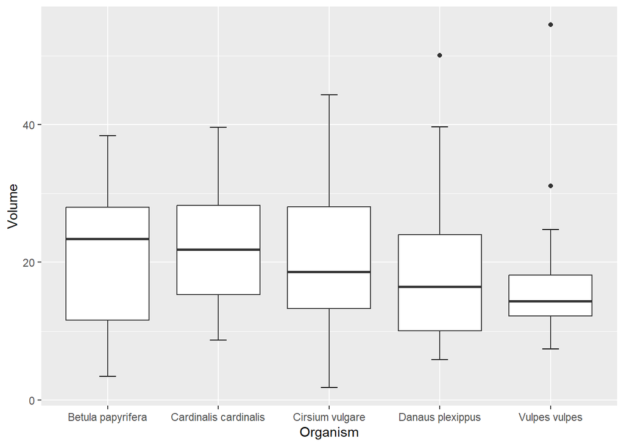

```r
library(ggplot2)
ggplot(measurementData, aes(x=Organism, y=Volume)) + stat_boxplot(geom = "errorbar",
               width = 0.15) + geom_boxplot()
```

The figure above shows B.Papyrifera with a higher median limb volume, while V.vulpes has the smallest interquartile range.

## Creating a Multi-Panel Plot for Volume Frequencies per Species

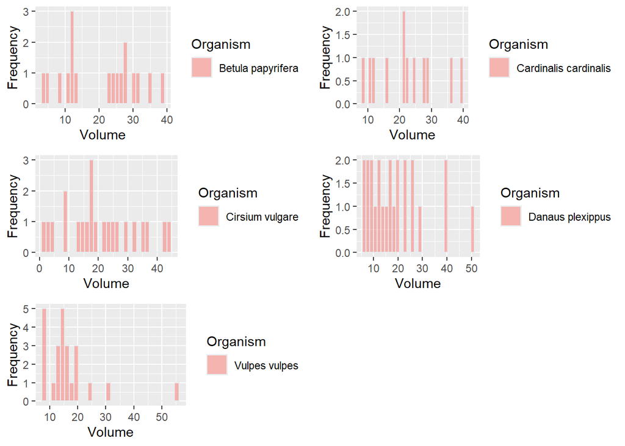

```r
install.packages("gridExtra", repos = "http://cran.us.r-project.org")
library(gridExtra)

#plot for Betula
Bp<-measurementData %>%
  filter(Organism == "Betula papyrifera")%>%
  ggplot(aes(x= Volume, fill= Organism)) +
    geom_histogram(color="#e9ecef", alpha = 0.5, bins = 30)+
  ylab("Frequency")

Cc<-measurementData %>%
  filter(Organism == "Cardinalis cardinalis")%>%
  ggplot(aes(x= Volume, fill= Organism)) +
    geom_histogram( color="#e9ecef", alpha = 0.5, bins = 30) +
  ylab("Frequency")

Cv<-measurementData %>%
  filter(Organism == "Cirsium vulgare")%>%
  ggplot(aes(x= Volume, fill=Organism)) +
    geom_histogram( color="#e9ecef", alpha = 0.5, bins = 30) +
  ylab("Frequency")

Dp<-measurementData %>%
  filter(Organism == "Danaus plexippus")%>%
  ggplot(aes(x= Volume, fill= Organism)) +
    geom_histogram(color="#e9ecef", alpha = 0.5, bins = 30) +
  ylab("Frequency")

Vv<-measurementData %>%
  filter(Organism == "Vulpes vulpes")%>%
  ggplot(aes(x= Volume, fill= Organism)) +
    geom_histogram( color="#e9ecef", alpha = 0.5, bins = 30) +
  ylab("Frequency")

grid.arrange(Bp, Cc, Cv, Dp, Vv, nrow = 3)
```